# Effects of Stripe Width on Biting Fly Landing Rates in Painted Cows

Taylor Godfrey

December 2 2025

## Term Project Description

My project builds upon the study referenced below. I have proposed a potential follow-up experiment to extend the study’s findings. The project utilizes simulated data, structured and analyzed as if collected from a real experiment. While the outcomes do not provide scientific evidence, they showcase my skills in formulating and addressing relevant biological questions through statistics, experimental design, and programming.

### Article citation:

Kojima, T., Oishi, K., Matsubara, Y., Uchiyama, Y., Fukushima, Y., Aoki, N., Sato, S., Masuda, T., Ueda, J., Hirooka, H., & Kino, K. (2019). Cows painted with zebra-like striping can avoid biting fly attack. PLOS ONE, 14(10). https://doi.org/10.1371/journal.pone.0223447

### Brief statement on the primary conclusions from the original article that led to your followup experiment:

The article “Cows painted with zebra-like striping can avoid biting fly attack” by Kojima et al.(2019) concluded that cows painted with high-contrast black-and-white stripes experienced roughly half as many biting fly landings as cows painted only with black stripes or left unpainted. Although the exact mechanism remains unknown, the authors state that the high contrast stripes most likely interfere with the flies’ ability to properly detect motion. These results indicate that painting livestock could be a promising and safer alternative to pesticides which can be harmful for both humans and livestock. Since this study only consisted of one kind of stripe, I thought it would be useful to examine how different widths of the stripes affects the hourly rate at which the flies land on the cows.

## The Question

Does the width of black and white stripes of cows affect the average hourly rate of biting fly landings?

> Disclaimer: This project analyzes simulated data. The questions and hypotheses are real, but the results and conclusions are not.

### *Rationale and Background:*

It’s no secret that biting flies pose a major problem for animals and the livestock industry as more frequent biting fly landings drastically increases the risk for disease. While pesticides can be used to combat this, the consistent use of these chemicals can also have detrimental effects on humans, animals, and the environment. In hopes of steering away from pesticides, recent research has shown that altering the appearance of livestock can potentially reduce fly attacks. For example, Kojima et al. (2019) concluded that painting cows with high-contrast black-and-white stripes reduced biting fly landings by around 50% compared to the cows with only black stripes or no stripes at all. However, this study only tested one stripe pattern (black and white), raising the question of what other types of stripes (wide, medium, and narrow) can also affect fly landing frequencies. The idea that certain patterns can interfere with insect landing behavior directly corresponds to previously established research on insect motion detection. “Motion Detection in Insect Orientation and Navigation” by Srinivasan et al. (1999) reveals that flying insects respond differently to moving striped patterns based on the width of the stripes. When an insect is placed in a rotating drum with narrow stripes, the insect’s system produces a strong optomotor response since there is more rapid changes in the pattern. When placed in a drum with wide stripes, the insect’s system detects less frequent changes in the pattern resulting in a weaker optomotor response. According to these results, it is evident that insects are highly sensitive to stripe width and certain patterns of stripes can greatly affect how they come in contact with their environment. Understanding how insects interact and navigate landing on surfaces helps researchers get closer to finding a practical and safer alternative to protect livestock from biting flies rather than using pesticides.

## Hypotheses

#### *Null Hypothesis:*

There is no difference in the average hourly fly landings among cows painted with wide, medium, or narrow stripes.

#### *Alternative Hypothesis:*

At least one of the painted cow groups (wide, medium, or narrow) has a different number of average hourly fly landings compared to the others.

## Experimental Design

This study uses a randomized single-factor experimental design to compare the hourly fly landing rate across cows painted with either wide, medium, or narrow stripes. Each of the stripe treatment groups consists of multiple independent observations, ultimately allowing for a strong comparison amongst the groups. Cows are randomly assigned to a stripe pattern (either wide, medium, or narrow) to help reduce bias and ensure that treatment is distributed evenly. Despite the fact that a no-paint control control group is not present, the three different treatments allow for us to still distinguish between any potential effects that stripe width has on average fly landing rate. Ideally, these fly landings would be counted from viewing video recordings by individuals who are blind to the treatment to further minimize any observational bias.

#### *Explanatory and Response Variables:*

The explanatory, or independent variable, is stripe width which has three categorical levels: wide, medium, and narrow. The response, or independent variable, is the average number of biting fly landings per cow per hour.

#### *Alpha:*

0.05

#### *Alpha justification:*

A significance level, or alpha of 0.05 is used because it provides a reasonable probability of making a Type I error (false positive). It is also often considered the standard level in biological research since it accurately acknowledges the potential of this error without creating an overly high false positive risk.

#### *Power:*

0.8

#### *Power justification:*

A power level of 0.8 is used because it provides a strong probability of correctly detecting a true effect of the treatment, if one exists. Setting the power to 0.8 keeps the probability of a Type II error (false negative) reasonable at beta=0.2 which helps to prevent underpowered studies.

#### *Effect Size:*

Medium

#### *Effect Size justification:*

A medium effect size is chosen because it refrains from over or underestimating the strength of the treatment effects without having strong prior evidence. Having a medium effect size also allows for a reasonable sample size, while still being able to identify any meaningful biological observations or changes.

#### *Sample size:*

53

#### *Sample size justification:*

When using the Power Analysis application, I set up the following conditions: alpha=0.05, power=0.8, and effect size=medium. With those condition in place, the application states that a sample size of 53 is necessary in order to detect meaningful differences among treatments. 53 is an appropriate sample size since we are still able to observe significant effects without having an unreasonably large sample size.

## Data Analysis Plan

One-way ANOVA

A one-way ANOVA is appropriate since this experiment includes an independent categorical variable (stripe width) with three groups/levels as well as a continuous dependent variable. ANOVA is preferred here since it is able to test for differences amongst groups while controlling Type I error better than performing multiple t-tests would. If ANOVA states there are any significant effects, Tukey’s HSD post-hoc test will be performed to determine which specific groups differ from one another.

## Assumptions and Exploratory Data Analysis (EDA)

The assumptions of a One-way ANOVA are independent observations, normally distributed data, and equal variance among groups.

```r
#USE THIS BLOCK TO INPUT NECESSARY CODE.

#Loads Tidyverse
library(tidyverse)
#Loads CSV file and stores it as "data."
data <- read_csv("tgodfrey.csv")
#Displays first six rows of data
head(data)
```

| wide | narrow | medium |
| --- | --- | --- |
| 45.311 | 3.612 | 18.750 |
| 16.832 | 28.723 | 15.421 |
| 18.150 | 4.177 | 25.947 |
| 26.943 | 23.494 | 4.105 |
| 29.149 | 1.782 | 41.498 |
| 8.560 | 19.581 | 27.558 |

```r
#Reshapes data from a wide format to a long format.
data_long <- data %>%
  pivot_longer(
    cols = everything(),
    names_to = "StripeType",
    values_to = "FlyLandings"
  )

#Displays first six rows of data in a long format.
head(data_long)
```

| StripeType | FlyLandings |
| --- | --- |
| wide | 45.311 |
| narrow | 3.612 |
| medium | 18.750 |
| wide | 16.832 |
| narrow | 28.723 |
| medium | 15.421 |

```r
#Calculates summary statistics(mean, standard deviation, maxs, and mins) and displays them in a table.
data_long %>%
  group_by(StripeType) %>%
  summarize(
    mean_landings = mean(FlyLandings),
    sd_landings = sd(FlyLandings),
    min = min(FlyLandings),
    max = max(FlyLandings),
    n = n()
  ) %>%
  knitr::kable(caption = "Descriptive Statistics for Fly Landings by Stripe Type")
```

Descriptive Statistics for Fly Landings by Stripe Type

| StripeType | mean_landings | sd_landings | min | max | n |
| --- | --- | --- | --- | --- | --- |
| medium | 24.26864 | 15.69004 | 1.458 | 60 | 53 |
| narrow | 29.66919 | 80.86936 | 1.003 | 600 | 53 |
| wide | 22.47281 | 12.36888 | 1.315 | 60 | 53 |

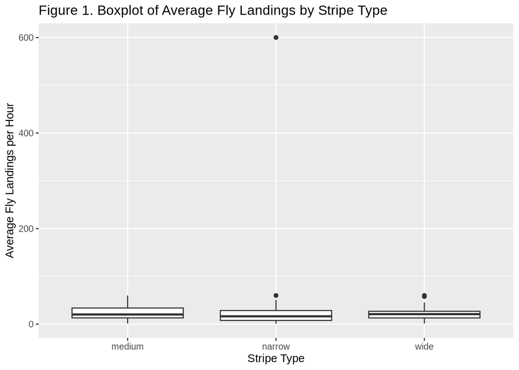

```r
#Generates a boxplot with x = different stripe types and y = number of landings
ggplot(data_long, aes(x = StripeType, y = FlyLandings)) +
  geom_boxplot() +
  labs(title = "Figure 1. Boxplot of Average Fly Landings by Stripe Type",
       y = "Average Fly Landings per Hour",
       x = "Stripe Type")
```

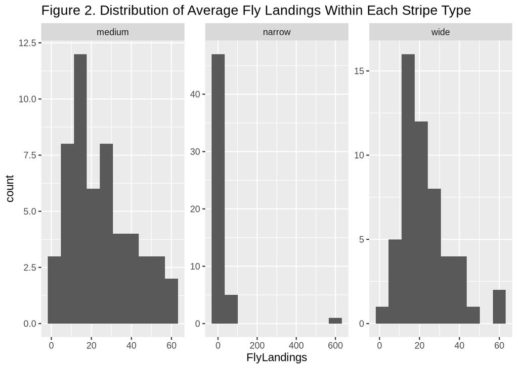

```r
#Generates a histogram to help assess normality.
ggplot(data_long, aes(x = FlyLandings)) +
  geom_histogram(bins = 10) +
  facet_wrap(~ StripeType, scales = "free") +
  labs(title = "Figure 2. Distribution of Average Fly Landings Within Each Stripe Type")
```

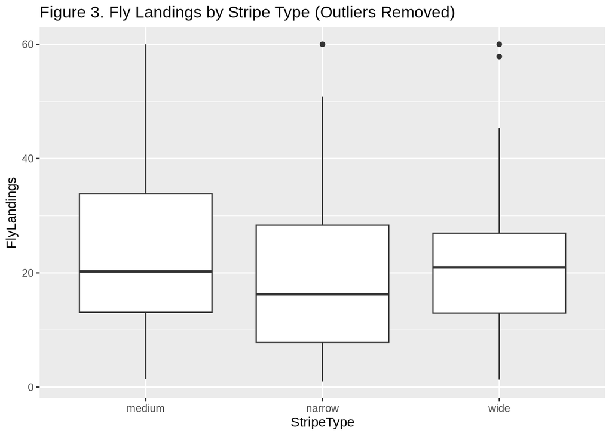

```r
#Filters out extreme outliers over 100 and creates a boxplot of the cleaned data to improve variance and normality.
data_clean <- data_long %>%
  filter(FlyLandings <= 100)
ggplot(data_clean, aes(x = StripeType, y = FlyLandings)) +
  geom_boxplot() +
  labs(title = "Figure 3. Fly Landings by Stripe Type (Outliers Removed)")
```

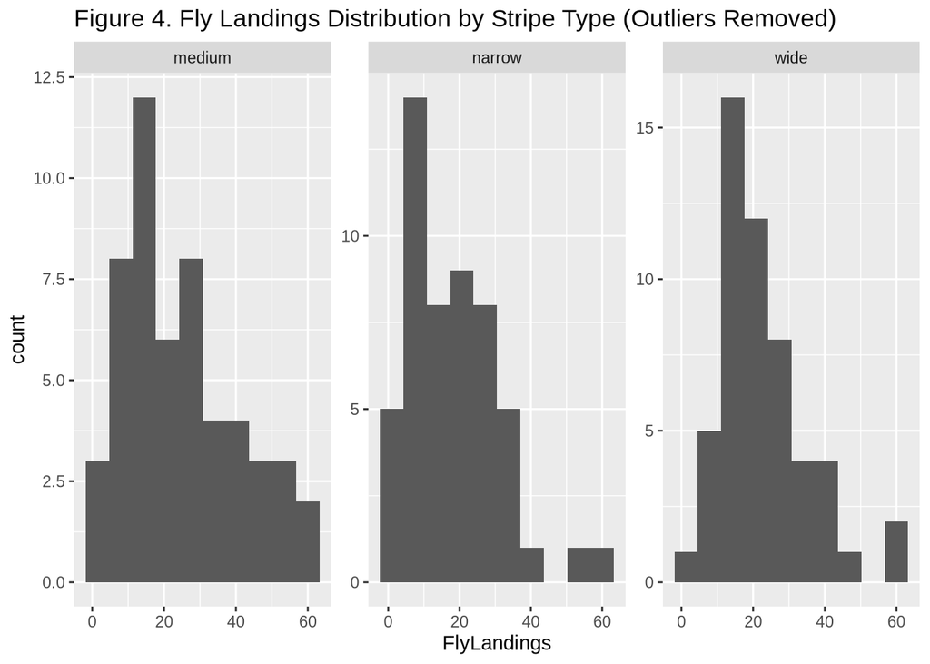

```r
#Generates a histogram of the cleaned data without the extreme outliers.
ggplot(data_clean, aes(x = FlyLandings)) +
  geom_histogram(bins = 10) +
  facet_wrap(~StripeType, scales="free") +
  labs(title = "Figure 4. Fly Landings Distribution by Stripe Type (Outliers Removed)")
```

```r
#Include code to read your data, display it, create exploratory visualizations, and check for outliers.
# Make sure to use # to add annotations that clearly describe the purpose of each function.
```

## Transformation Analysis

#### *Box-Cox Analysis and Transformation Choice:*

After performing the Box-Cox analysis, the optimal lambda value produced was 0.40543555. Since this value is in between 0.25 and 0.75, I selected a square root transformation for the FlyLandings variable. This transformation aligns with the optimal lambda value since it improves normality and stabilizes the variance of FlyLandings.

```r
#USE THIS BLOCK TO INPUT NECESSARY CODE.
#Include code to:
library(tidyverse)
library(MASS)
library(car)
#- Perform Box-Cox analysis and identify optimal lambda
model <- lm(FlyLandings ~ StripeType, data = data_clean)
pt <- powerTransform(model)
lambda <- pt$lambda
print(lambda)
```

```
##        Y1
## 0.4054355
```

```r
#- Create your chosen transformation
data_clean <- data_clean %>%
    mutate(FlyLandings_sqrt = sqrt(FlyLandings))
head(data_clean)
```

| StripeType | FlyLandings | FlyLandings_sqrt |
| --- | --- | --- |
| wide | 45.311 | 6.731345 |
| narrow | 3.612 | 1.900526 |
| medium | 18.750 | 4.330127 |
| wide | 16.832 | 4.102682 |
| narrow | 28.723 | 5.359384 |
| medium | 15.421 | 3.926958 |

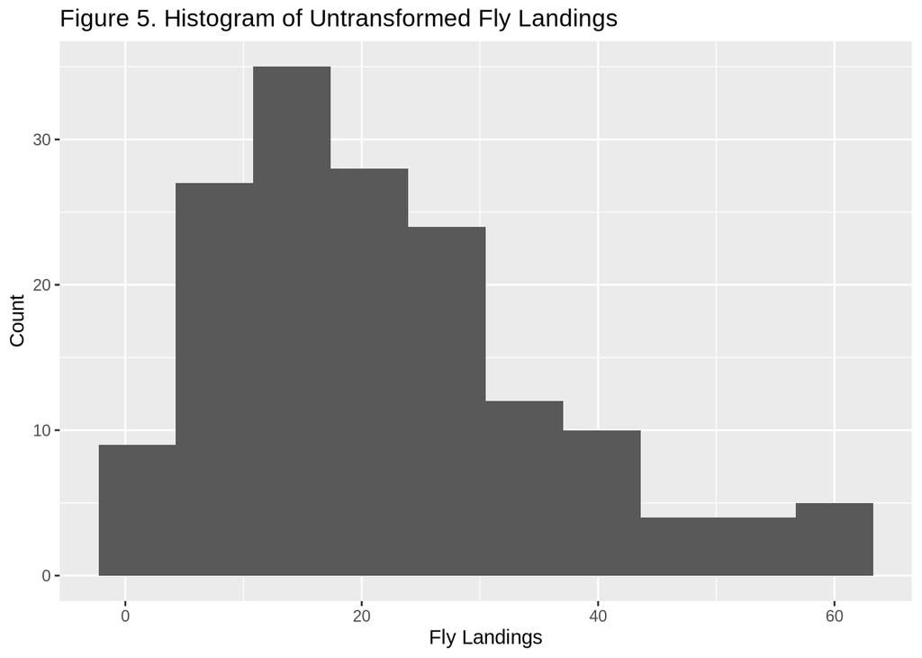

```r
#- Create visualizations comparing untransformed vs transformed data
ggplot(data_clean, aes(x = FlyLandings)) +
  geom_histogram(bins = 10) +
  labs(title = "Figure 5. Histogram of Untransformed Fly Landings",
       x = "Fly Landings",
       y = "Count")
```

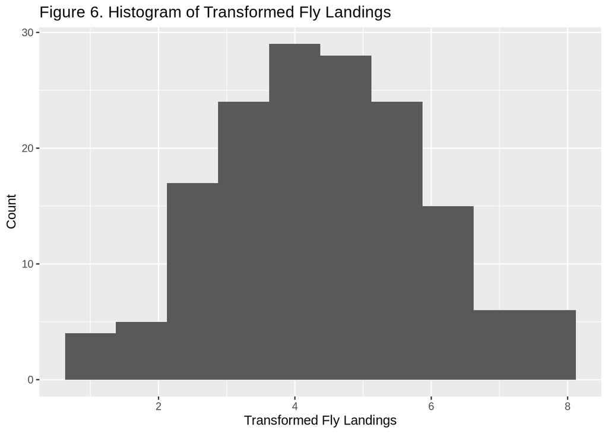

```r
ggplot(data_clean, aes(x = FlyLandings_sqrt)) +
  geom_histogram(bins = 10) +
  labs(title = paste("Figure 6. Histogram of Transformed Fly Landings"),
       x = "Transformed Fly Landings",
       y = "Count")
```

```r
#- Run normality tests (e.g., KS tests) on both versions
ks_untrans <- ks.test(scale(data_clean$FlyLandings), "pnorm")
ks_trans   <- ks.test(scale(data_clean$FlyLandings_sqrt), "pnorm")
#- Display your results clearly
print(ks_untrans)
```

```
##
##  Asymptotic one-sample Kolmogorov-Smirnov test
##
## data:  scale(data_clean$FlyLandings)
## D = 0.098502, p-value = 0.0932
## alternative hypothesis: two-sided
```

```r
print(ks_trans)
```

```
##
##  Asymptotic one-sample Kolmogorov-Smirnov test
##
## data:  scale(data_clean$FlyLandings_sqrt)
## D = 0.04193, p-value = 0.944
## alternative hypothesis: two-sided
```

#### *Transformation Decision:*

After performing the square root transformation, I decided to use the transformed data for my primary statistical analysis because it has a more normal distribution compared to the untransformed data. The p-value of the transformed data is much higher at 0.944, while the p-value of the untransformed data is 0.0932. A higher p-value indicates that the transformed data is more normally distributed ultimately making it more appropriate for ANOVA.

## Primary Statistical Analysis

```r
#USE THIS BLOCK TO INPUT NECESSARY CODE.
#Conduct your primary statistical test and any post-hoc tests as needed.
anova_model <- aov(FlyLandings_sqrt ~ StripeType, data = data_clean)

#Performs post-hoc test.
summary(anova_model)
```

```
##              Df Sum Sq Mean Sq F value Pr(>F)
## StripeType    2   10.9   5.458   2.465 0.0884 .
## Residuals   155  343.2   2.214
## ---
## Signif. codes:  0 '***' 0.001 '**' 0.01 '*' 0.05 '.' 0.1 ' ' 1
```

```r
tukey_results <- TukeyHSD(anova_model)
print(tukey_results)
```

```
##   Tukey multiple comparisons of means
##     95% family-wise confidence level
##
## Fit: aov(formula = FlyLandings_sqrt ~ StripeType, data = data_clean)
##
## $StripeType
##                      diff        lwr        upr     p adj
## narrow-medium -0.59587502 -1.2832047 0.09145462 0.1035412
## wide-medium   -0.08225306 -0.7663019 0.60179575 0.9563605
## wide-narrow    0.51362196 -0.1737077 1.20095160 0.1836750
```

## Data Visualization

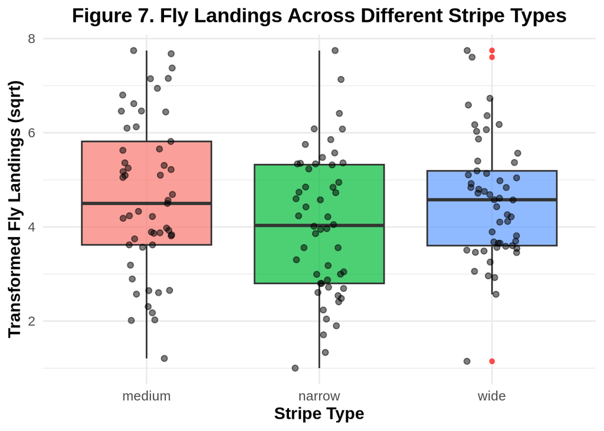

```r
#USE THIS BLOCK TO INPUT NECESSARY CODE.
#Create a single well-designed figure using ggplot that clearly shows patterns in your data.
ggplot(data_clean, aes(x = StripeType, y = FlyLandings_sqrt, fill = StripeType)) +
  geom_boxplot(alpha = 0.7, outlier.shape = 16, outlier.color = "red") +
  geom_jitter(width = 0.15, alpha = 0.5, color = "black") +
  labs(
    title = "Figure 7. Fly Landings Across Different Stripe Types",
    x = "Stripe Type",
    y = "Transformed Fly Landings (sqrt)",
    fill = "Stripe Type"
  ) +
  theme_minimal(base_size = 14) +
  theme(
    legend.position = "none",
    plot.title = element_text(face = "bold", hjust = 0.5),
    axis.title = element_text(face = "bold")
  )
```

#### *Figure Caption:*

Figure 7. Boxplot of transformed average fly landings across 3 types of stripes. Each point represents an individual observation. The plot shows the median and distribution of fly landings across the stripe types. Although the narrow stripes overall have less average fly landings, it is not enough to be significant. There are no statistically significant observed differences between the groups.

## Conclusions

The overall goal of this study was to determine whether or not painting cows with different stripe widths (wide, medium, or narrow) affected the number of flies that landed on them. After I used a square root transformation to improve variance and normality for ANOVA, I tested for any differences between the three groups. The ANOVA did not detect any statistically significant effects to show that stripe width has an effect on fly landings as it resulted in a p-value of 0.0884 which is above the 0.05 significance level. While patterns in Figure 7 do suggest that the cows with narrow stripes tended to have overall less less fly landings compared to the cows with medium stripes, the differences between the groups were not large enough to constitute statistical significance. I also performed the Tukey HSD post-hoc test which showed no significant differences between groups, supporting the conclusion that there is not enough evidence to say that stripe width has a significant effect on biting fly landings. Due to the fact that the effect did not reach a level of statistical significance, the results should be interpreted with caution. While it is possible that differences do exist between the stripe width groups, it could also be the case that the sample size was not large enough to detect it. It also appears that majority of the variation in the data came from differences within the groups as opposed to between the groups. Another factor that could have contributed to the lack of differences between groups is the fact that this is a simulated data set and not reflective of real world environmental conditions. Because the simulated data fails to capture the reality of fly behavior and other ecological conditions, the patterns observed in this study may not be indicative of a field study. However, according to Srinivasan et al. (1999), high-contrast and narrow stripe patterns seem to disrupt insect motion detection stronger than lower-contrast stripes. Since my data my dataset was simulated and lacks the conditions and constraints of Srinivasan et al. (1999), we are unable to accurately determine whether or not more narrow stripes actually help reduce fly landings. It can be concluded that any differences observed in my experiment are likely to be the results of simulated conditions rather than actual biological effects.

## Future Directions

Future research on the effects of stripe patterns on fly landings on livestock could be improved by strengthening experimental conditions. For example, in real world settings, fly behavior is influenced by numerous other factors such as wind, temperature, and time of day. By incorporating these factors into future studies, it will provide us with a more accurate conclusion of insect behavior as well as allow us to see how other environmental conditions play a role. If there were no restrictions, a larger sample size could also improve the strength of the study it makes it easier to detect true differences between the stripe groups.

## Citations

Kojima, T., Oishi, K., Matsubara, Y., Uchiyama, Y., Fukushima, Y., Aoki, N., Sato, S., Masuda, T., Ueda, J., Hirooka, H., & Kino, K. (2019). Cows painted with zebra-like striping can avoid biting fly attack. PLOS ONE, 14(10). https://doi.org/10.1371/journal.pone.0223447

Srinivasan, M. V., Poteser, M., & Kral, K. (1999). Motion detection in insect orientation and navigation. Vision Research, 39(16), 2749–2766. https://doi.org/10.1016/s0042-6989(99)00002-4